# CAN7035 ML/AL Assignment LAQ2

Ka Yi Chan

2026-04-19

LAQ 2. (27 marks in total) All the data required for this LAQ are in ‘For_LAQ2_required_data.zip’

File ‘exp_data_ESCC_90samples.txt’ contains gene expression profiles of 90 oesophageal squamous cell carcinoma samples.

1. Perform the unsupervised clustering analysis using non-negative matrix factorization (NMF). Find the most appropriate number of clusters, and provide all the essential statistics and plots to support your clusters. (4 marks)

Load packages

```r
# Install.packages('NMF')
library(NMF)
# list all available algorithms
nmfAlgorithm()
```

```
##  [1] "brunet"    "KL"        "lee"       "Frobenius" "offset"    "nsNMF"
##  [7] "ls-nmf"    "pe-nmf"    "siNMF"     "snmf/r"    "snmf/l"
```

```r
# retrieve a specific algorithm: 'brunet'
nmfAlgorithm('brunet')
```

```
## <object of class: NMFStrategyIterative>
##  name: brunet [NMF]
##  objective: 'KL'
##  model: NMFstd
##  <Iterative schema>
##   onInit: none
##   Update: function (i, v, x, copy = FALSE, eps = .Machine$double.eps, ...)
##   Stop: 'connectivity'
##   onReturn: none
```

Load file ‘exp_data_ESCC_90samples.txt’ contains gene expression profiles of 90 oesophageal squamous cell carcinoma samples.

```r
escc_data <- read.table('/Users/kayivionachan/Documents/CAN7035 Machine Learning AI/CAN7035 Assignment/For_LAQ2_required_data/exp_data_ESCC_90samples.txt', header=T, row.names=1)
dim(escc_data)
```

```
## [1] 26540    90
```

```r
# Feature selection using MAD (Median Absolute Deviation)
escc_exp <- escc_data
mads=apply(escc_exp,1,mad)
escc_exp=escc_exp[rev(order(mads))[1:1500],]
dim(escc_exp)
```

```
## [1] 1500   90
```

```r
head(escc_exp)
```

```
##         TCGA.VR.A8EU.01 TCGA.LN.A8I0.01 TCGA.LN.A49Y.01 TCGA.LN.A4MQ.01
## SPRR3            5.0680          8.6270          7.3476         11.0373
## KRT13            3.2714          7.2487          9.6593         11.1449
## ALDH3A1          1.4482         10.0872          3.7143          8.0451
## ALDH1A1          1.4371          5.7640          5.8126          7.8408
## LGALS7B          5.9467          6.8194          7.8701          5.9110
## AKR1C3           7.2786          8.8084          3.9872          7.7458
##         TCGA.VR.AA7I.01 TCGA.IG.A3I8.01 TCGA.Z6.A8JD.01 TCGA.VR.A8EP.01
## SPRR3            6.5959          7.3356          5.4950         12.3350
## KRT13            7.2771          4.2599          6.4982         12.3483
## ALDH3A1          3.1006          3.4639          2.1497          4.3728
## ALDH1A1          1.7924          2.1439          0.8290          6.8900
## LGALS7B          8.7324          1.5055          5.2780          6.5601
## AKR1C3           2.5831          4.2879          2.0422          8.6977
##         TCGA.IG.A97H.01 TCGA.JY.A93F.01 TCGA.IG.A3YA.01 TCGA.LN.A49P.01
## SPRR3            0.4345          9.9485          9.7919          9.4364
## KRT13            3.8948          6.3308          8.8586          8.8567
## ALDH3A1          5.7824          1.2397          4.6802          7.9623
## ALDH1A1          0.8301          0.2639          6.6981          6.2714
## LGALS7B          2.2964          8.3267          3.8497          7.8298
## AKR1C3           5.2352          3.5608          5.0891          7.8317
##         TCGA.KH.A6WC.01 TCGA.JY.A6FG.01 TCGA.IG.A3Y9.01 TCGA.LN.A49W.01
## SPRR3           14.6970          9.8213          3.6781          0.1524
## KRT13           14.9689          6.5595          6.8001          1.2860
## ALDH3A1          7.3668          0.5969          3.9790          1.3647
## ALDH1A1          3.0689          0.6445          3.1444          2.3610
## LGALS7B          9.0775         10.2793          7.1267          1.0701
## AKR1C3           4.1571          3.1762          3.7399          1.5749
##         TCGA.VR.A8EZ.01 TCGA.LN.A49S.01 TCGA.LN.A7HW.01 TCGA.LN.A49L.01
## SPRR3            3.7952         12.3160          9.6717          0.1141
## KRT13            6.9701         12.8943          4.2047          1.0151
## ALDH3A1          7.6140          5.2964          8.6961          1.2023
## ALDH1A1          6.7874          5.1975          5.0495          3.2553
## LGALS7B          6.3523          0.4886          7.5606          5.8552
## AKR1C3           9.0573          4.9019          9.7909          1.0683
##         TCGA.Q9.A6FU.01 TCGA.IG.A6QS.01 TCGA.LN.A7HY.01 TCGA.L7.A56G.01
## SPRR3            0.5162          0.1272          9.1029         12.9126
## KRT13            5.6539          0.8652          8.8719         12.9439
## ALDH3A1          2.8239          3.8776          1.7433          3.6759
## ALDH1A1          3.9436          0.4165          1.5165          4.4738
```

[output cut: 106 more lines]

```
## AKR1C3           8.9071          3.7750          1.7716          7.7443
##         TCGA.VR.AA7B.01 TCGA.IG.A4P3.01 TCGA.LN.A5U6.01 TCGA.IG.A3QL.01
## SPRR3            3.2913         10.6353          1.5090          6.7732
## KRT13            3.8384         11.4123          2.5538          6.1629
## ALDH3A1          0.2694          6.3771          4.3056          8.0393
## ALDH1A1          1.0328          7.1395          1.2986          7.4646
## LGALS7B          2.9195          4.5918          1.7905          3.1472
## AKR1C3           0.7468          5.0668          8.2011          8.4092
##         TCGA.IG.A5B8.01 TCGA.L5.A88S.01
## SPRR3            9.7264          6.4795
## KRT13            0.9568          0.9797
## ALDH3A1          0.5289          3.3022
## ALDH1A1          0.3262          2.7778
## LGALS7B          3.9784          2.7040
## AKR1C3           3.8018          3.7936
```

Determine optimal K using NMF rank survey – Test K = 2 to 6, running 10 iterations per rank to evaluate clustering quality.

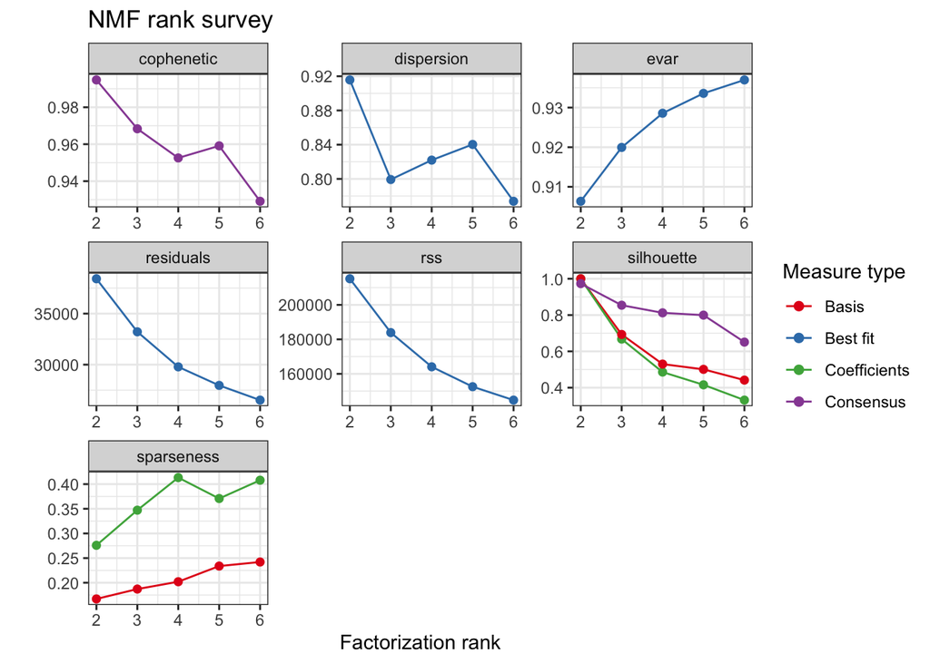

```r
# Set seed to ensure reproducibility
escc_estim.r <- nmf(escc_exp, 2:6, nrun=10, seed=420)

plot(escc_estim.r)
```

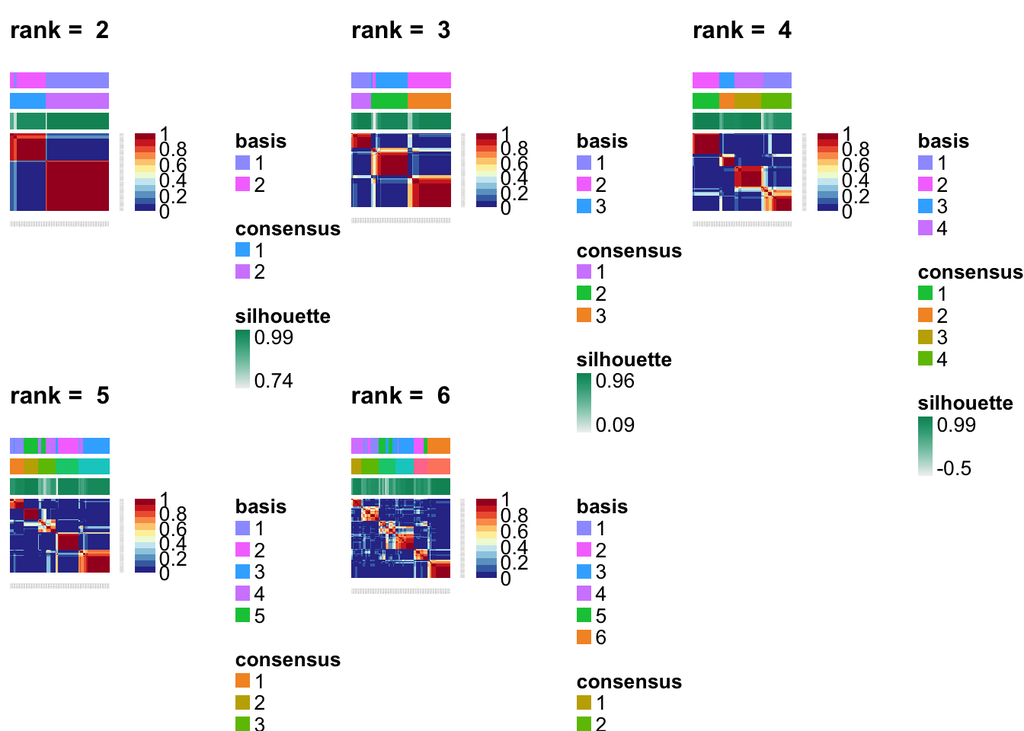

```r
consensusmap(escc_estim.r)
```